# Week 3: R Programming

September 10, 2017

## Questions?

## Before we get started – comments

- The `#` character allows you to make **comments** in your `R` code
- Comments are lines of text that are read but not evaluated by `R`
- Comments are used to add notes to your code to add context
- We'll talk more about them next week

## Before we get started – scripts

`R` scripts are text files with the file extension `.R`. An example would be something like: `my-script.R`. Scripts will often contain **related** sets of functions and code.

## Overview

- Control Flow
- Looping the `R` way with *ply functions

## Control Flow

## Control Flow

- [Control Flow](https://en.wikipedia.org/wiki/Control_flow) contstructs can be thought of as building blocks
- They allow you to specify complex rules/behavior of `R` code
- Invoked with *reserved* words in `R`

```r
?`if`
```

## `if`, `else if`, `else`

- similar to other languates, `R` allows for `if.. else...` blocks
- the general structure is as follows:

```r
if (condition_one) {
  # do this if condition_one == TRUE
} else if (condition_two) {
  # do this if condition_one == FALSE
  # and condition_two == TRUE
} else {
  # do this if condition_one == FALSE &
  # condition_tow == FALSE
}
```

A trivial example:

```r
x <- 0
if (x < 0) {
   print("Negative number")
} else if (x > 0) {
   print("Positive number")
} else {
  print("Zero")
}
```

```
## [1] "Zero"
```

## Loops

- we'll typically use `if.. else...` blocks inside of *loops*
- *loops* are used in programming to repeatedly perform something
- `R` has three types of loops
  - `for`
  - `while`
  - `repeat`

## `for` loops

- similar to `for` loops in other languages
- useful for iterating over things we want to *do* something to

the syntax is:

```r
for (var in seq) {
  # do something
}
```

## `for` loop schematic

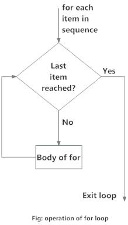

floop

```r
for (var in vec) {
  # do something
}
```

A very basic example – print the numbers from 1 to 5:

```r
for (i in 1:5) {
  print(i)
}
```

```
## [1] 1
## [1] 2
## [1] 3
## [1] 4
## [1] 5
```

Another basic example – cumulative sums:

```r
running_total <- 0
to_sum <- seq(10, 1000, 22)
for (value in to_sum) {
  running_total <- running_total + value
}
running_total
```

```
## [1] 23230
```

Cumulative sums – alternative approach

```r
running_total <- 0
to_sum <- seq(10, 1000, 22)
for (i in 1:length(to_sum)) {
  running_total <- running_total + to_sum[i]
}
running_total
```

```
## [1] 23230
```

## Nesting Loops

You can loop nest another loop with in a loop

```r
for(i in 1:3) {
  for(j in 1:2) {
    print(paste0('i = ', i, '; j = ', j))
  }
}
```

```
## [1] "i = 1; j = 1"
## [1] "i = 1; j = 2"
## [1] "i = 2; j = 1"
## [1] "i = 2; j = 2"
## [1] "i = 3; j = 1"
## [1] "i = 3; j = 2"
```

## Nesting Loops

Often used for populating matricies

```r
ctr <- 1
mat <- matrix(NA, ncol = 3, nrow = 2)
for(i in 1:2) {
  for(j in 1:3) {
    mat[i, j] <- ctr
    ctr <- ctr + 1
  }
}
mat
```

```
##      [,1] [,2] [,3]
## [1,]    1    2    3
## [2,]    4    5    6
```

## Loops & `if.. else...`

You will mix loops with `if.. else...` blocks often. Here we use the two to print out all the even numbers between 1 and 10:

```r
for (i in 1:10) {
  if (i %% 2 == 0) {
    print(i)
  }
}
```

```
## [1] 2
## [1] 4
## [1] 6
## [1] 8
## [1] 10
```

## `for` Loops – Why?

- [don't repeat yourself (DRY)](https://en.wikipedia.org/wiki/Don%27t_repeat_yourself)
- makes the code more compact, readable and maintainable and
- usually saves you some typing and effort

## `while` Loops

- `while` loops repeatedly evaluate an expression until a condition becomes false
- the basic syntax is as follows

```r
while (some_condition) {
  # keep running this until
  # some_condition is FALSE
}
```

## `while` loop schematic

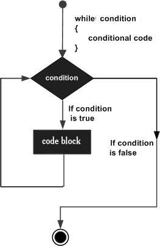

floop

## `while` loop examples

```r
i <- 1
while (i < 6) {
   print(i)
   i <- i + 1
}
```

```
## [1] 1
## [1] 2
## [1] 3
## [1] 4
## [1] 5
```

## `break` – getting out of loops early

- `break` can be used to jump out of loops early
- when `break` is encountered, `R` jumps out of the loop into the enclosing expression

```r
x <- 1:5
for (val in x) {
  if (val == 3) {
      break
  }
  print(val)
}
```

```
## [1] 1
## [1] 2
```

## `next` – skipping an iteration in a loop

```r
x <- 1:5
for (val in x) {
    if (val == 3) {
        next
    }
    print(val)
}
```

```
## [1] 1
## [1] 2
## [1] 4
## [1] 5
```

## `repeat` loops

- `repeat` loops let you repeat the same chunk of code over an over
- used much less frequently than other two types of loops
- need to hard code a stopping condition (or else!)

```r
repeat {
  # do this over and over until
  # stop_condition == TRUE

 if (stop_condition) {
    break # breaks repeat loop
 }
}
```

## Learning About the `*ply` Family

## The `*ply` family

There are many members of the `*ply` family. Here's a brief description of each one:

- `apply`: Apply Functions Over Array Margins
- `lapply`: Apply a Function over a List or Vector
- `sapply`: Apply a Function over a List or Vector
- `tapply`: Apply a Function Over a Ragged Array
- `replicate`: The oddly named one…

## `apply`

`apply` lets us *apply* a function to rows or columns of a matrix (or other dimensions of an array). The basic usage is:

```
apply(X, MARGIN, FUN, ...)
```

[figure not shown]

floop

## `apply` example – replicating `colSums`

```r
mat <- matrix(rnorm(200), nrow = 20, ncol = 10)
col_sums <- apply(X = mat, MARGIN = 2, FUN = sum)
all(col_sums == colSums(mat))
```

```
## [1] TRUE
```

```r
row_sums <- apply(X = mat, MARGIN = 1, FUN = sum)
all(col_sums == colSums(mat))
```

```
## [1] TRUE
```

## lapply and sapply

- `lapply` & `sapply` are more or less the same function under the hood.
- `sapply`, by default, will tries to *simplify* output
- both apply a function to each element of a vector or list

```r
my_vec <- seq(0, 30, 6)
lapply(my_vec, is.numeric)
```

```
## [[1]]
## [1] TRUE
##
## [[2]]
## [1] TRUE
##
## [[3]]
## [1] TRUE
##
## [[4]]
## [1] TRUE
##
## [[5]]
## [1] TRUE
##
## [[6]]
## [1] TRUE
```

## lapply and sapply cont.

```r
sapply(my_vec, is.numeric)
```

```
## [1] TRUE TRUE TRUE TRUE TRUE TRUE
```

```r
sapply(my_vec, is.numeric, simplify = FALSE)
```

```
## [[1]]
## [1] TRUE
##
## [[2]]
## [1] TRUE
##
## [[3]]
## [1] TRUE
##
## [[4]]
## [1] TRUE
##
## [[5]]
## [1] TRUE
##
## [[6]]
## [1] TRUE
```

```r
unlist(lapply(my_vec, is.numeric))
```

```
## [1] TRUE TRUE TRUE TRUE TRUE TRUE
```

## lapply and sapply cont.

```r
unlist(lapply(my_vec, is.numeric))
```

```
## [1] TRUE TRUE TRUE TRUE TRUE TRUE
```

## `tapply`

- `tapply` applies a function to subsets of a vector.
- Often used for computing summary statistics

```r
tapply(iris$Petal.Length, iris$Species, mean)
```

```
##     setosa versicolor  virginica
##      1.462      4.260      5.552
```

```r
tapply(iris$Petal.Length, iris$Species, sd)
```

```
##     setosa versicolor  virginica
##  0.1736640  0.4699110  0.5518947
```

## To the lab…

[link](https://courses.aquinas.edu/pluginfile.php/116697/mod_resource/content/4/week-3-lab-homework.html)